# crime_analysis_Nantes

### Analyse de l'évolution de la criminalité à Nantes

#### Objectifs de l'étude :

1. Quels sont les crimes les plus courants.
2. Savoir comment la criminalité a évolué ces dernières années à Nantes.
3. Si la tendance se poursuit, quels sont les crimes qui connaîtront la plus forte croissance à l'avenir.
4. Est-ce qu'il a une correlation entre le crime et le chomage ?

**Sources :**

Criminalité

https://www.data.gouv.fr/fr/datasets/crimes-et-delits-enregistres-par-les-services-de-gendarmerie-et-de-police-depuis-2012/

Chomage

https://data.paysdelaloire.fr/explore/dataset/234400034_chomage-zone-t1-2003-t4-2017/table/

https://statistiques.pole-emploi.org/stmt/defm?fi=52&ss=1

### Récupération et préparation des données

```python
# Get data

import os

current_folder = globals()['_dh'][0]

# Calculating path to the input data
data_location = os.path.join(current_folder,'data\crimes-et-delits-enregistres_PN.xlsx')

import pandas as pd
import openpyxl
import xlrd

multi_sheet_file = pd.ExcelFile(data_location, engine='openpyxl')
```

#### Créer un jeu de données pour chaque feuille du fichier Excel

```python
def dataframe_dict(multi_sheet_file):
    """
    Create one Dataframe for each sheet in a Excel file.
    """
    # Gets the sheet names in the file
    excel_sheet_names = multi_sheet_file.sheet_names

    dict_of_sheets = {}
    for sheet in excel_sheet_names:
        dict_of_sheets["sheet_" + sheet] = pd.read_excel(multi_sheet_file, sheet_name=sheet, header = 1)
         #  header = 1 for use second row as a name of columns

    return dict_of_sheets
```

```python
police_records_dict = dataframe_dict(multi_sheet_file)

# Names of dataframes
print(police_records_dict.keys())
```

```
dict_keys(['sheet_Services PN 2012', 'sheet_Services PN 2013', 'sheet_Services PN 2014', 'sheet_Services PN 2015', 'sheet_Services PN 2016', 'sheet_Services PN 2017', 'sheet_Services PN 2018', 'sheet_Services PN 2019', 'sheet_Services PN 2020'])
```

```python
# Get one dataframe from dictionary
police_record_2012 = police_records_dict.get('sheet_Services PN 2012')

# View an extract from the dataframe
police_record_2012.head()
```

|  | Code index | Libellé index \ CSP | Type de crime | DIDPAF PREVESSIN 01 | CIAT DE BOURG EN BRESSE | CIAT D'OYONNAX | CIAT DE CHATEAU THIERRY | CIAT DE LAON | CIAT DE SOISSONS | CIAT DE ST QUENTIN | ... | CIAT DE ST ANDRE | CIAT DE ST PIERRE | CIAT DU PORT | DPAF MAYOTTE 976 | CIAT DE MAMOUDZOU | DPAF POLYNESIE FRANCAISE 987 | CIAT DE PAPEETE | DPAF NOUVELLE CALEDONIE 988 | CIAT DE NOUMEA | ANNEE |
| --- | --- | --- | --- | --- | --- | --- | --- | --- | --- | --- | --- | --- | --- | --- | --- | --- | --- | --- | --- | --- | --- |
| 0 | 1 | Règlements de compte entre malfaireurs | Autres délits | 0 | 0 | 0 | 0 | 0 | 0 | 0 | ... | 0 | 0 | 0 | 0 | 0 | 0 | 0 | 0 | 0 | 2012 |
| 1 | 2 | Homicides pour voler et à l'occasion de vols | Homicides | 0 | 0 | 0 | 0 | 0 | 0 | 0 | ... | 0 | 0 | 0 | 0 | 0 | 0 | 0 | 0 | 0 | 2012 |
| 2 | 3 | Homicides pour d'autres motifs | Homicides | 0 | 0 | 0 | 0 | 0 | 0 | 0 | ... | 1 | 1 | 3 | 0 | 2 | 0 | 0 | 0 | 3 | 2012 |
| 3 | 4 | Tentatives d'homicides pour voler et à l'occas... | Tentatives d'homicide | 0 | 0 | 0 | 0 | 0 | 0 | 0 | ... | 0 | 0 | 0 | 0 | 0 | 0 | 1 | 0 | 0 | 2012 |
| 4 | 5 | Tentatives homicides pour d'autres motifs | Tentatives d'homicide | 0 | 0 | 0 | 0 | 0 | 0 | 0 | ... | 1 | 1 | 0 | 0 | 4 | 0 | 0 | 0 | 1 | 2012 |

5 rows × 611 columns

```python
# Iterating the columns
for column_name in police_record_2012.columns:
    if "nantes" in column_name.lower() : # Filter only records from Nantes
        print(column_name)
```

```
SPAFA NANTES ATLANTIQUE
CIAT CENTRAL DE NANTES
```

```python
police_record_2012 = police_record_2012[["SPAFA NANTES ATLANTIQUE","CIAT CENTRAL DE NANTES"]].apply(pd.to_numeric)

print(police_record_2012.info())
police_record_2012.describe()
```

```
<class 'pandas.core.frame.DataFrame'>
RangeIndex: 107 entries, 0 to 106
Data columns (total 2 columns):
SPAFA NANTES ATLANTIQUE    107 non-null int64
CIAT CENTRAL DE NANTES     107 non-null int64
dtypes: int64(2)
memory usage: 1.8 KB
None
```

|  | SPAFA NANTES ATLANTIQUE | CIAT CENTRAL DE NANTES |
| --- | --- | --- |
| count | 107.000000 | 107.000000 |
| mean | 1.383178 | 323.000000 |
| std | 6.016714 | 659.842405 |
| min | 0.000000 | 0.000000 |
| 25% | 0.000000 | 1.000000 |
| 50% | 0.000000 | 13.000000 |
| 75% | 0.000000 | 275.500000 |
| max | 45.000000 | 2860.000000 |

#### Conter dans une seule colonne tous les crimes commis dans cette ville

```python
# Calculate in a single column all the crimes committed in that city
police_record_2012["Nantes"] = police_record_2012["SPAFA NANTES ATLANTIQUE"] + police_record_2012["CIAT CENTRAL DE NANTES"]
```

#### Organiser / concatener tout dans un seul jeu de données

```python
# Transforming the police records dictionary to list
police_records_list = []

for key, value in police_records_dict.items():
    police_records_list.append(value)
```

```python
police_records_list[1].head() # police record 2013
```

|  | Code index | Libellé index \ CSP | Type de crime | DIDPAF PREVESSIN 01 | CIAT DE BOURG EN BRESSE | CIAT D'OYONNAX | CIAT DE CHATEAU THIERRY | CIAT DE LAON | CIAT DE SOISSONS | CIAT DE ST QUENTIN | ... | CIAT DE ST ANDRE | CIAT DE ST PIERRE | CIAT DU PORT | DPAF MAYOTTE 976 | CIAT DE MAMOUDZOU | DPAF POLYNESIE FRANCAISE 987 | CIAT DE PAPEETE | DPAF NOUVELLE CALEDONIE 988 | CIAT DE NOUMEA | ANNEE |
| --- | --- | --- | --- | --- | --- | --- | --- | --- | --- | --- | --- | --- | --- | --- | --- | --- | --- | --- | --- | --- | --- |
| 0 | 1 | Règlements de compte entre malfaireurs | Autres délits | 0 | 0 | 0 | 0 | 0 | 0 | 0 | ... | 0 | 0 | 0 | 0 | 0 | 0 | 0 | 0 | 0 | 2013 |
| 1 | 2 | Homicides pour voler et à l'occasion de vols | Homicides | 0 | 0 | 0 | 0 | 0 | 0 | 0 | ... | 0 | 0 | 0 | 0 | 0 | 0 | 0 | 0 | 0 | 2013 |
| 2 | 3 | Homicides pour d'autres motifs | Homicides | 0 | 0 | 1 | 0 | 2 | 0 | 0 | ... | 0 | 1 | 2 | 0 | 1 | 0 | 0 | 0 | 7 | 2013 |
| 3 | 4 | Tentatives d'homicides pour voler et à l'occas... | Tentatives d'homicide | 0 | 0 | 0 | 0 | 0 | 1 | 0 | ... | 0 | 2 | 0 | 0 | 0 | 0 | 0 | 0 | 0 | 2013 |
| 4 | 5 | Tentatives homicides pour d'autres motifs | Tentatives d'homicide | 0 | 0 | 0 | 0 | 4 | 1 | 0 | ... | 0 | 1 | 0 | 0 | 1 | 0 | 0 | 0 | 1 | 2013 |

5 rows × 606 columns

```python
police_records_new_list = []

for dataframe in police_records_list :

    # Filter only records from Nantes and change the datatype from text to numeric
    dataframe[["SPAFA NANTES ATLANTIQUE","CIAT CENTRAL DE NANTES"]] = dataframe[["SPAFA NANTES ATLANTIQUE","CIAT CENTRAL DE NANTES"]].apply(pd.to_numeric)
    # Save only one column from Nantes
    dataframe["Delits enregistres"] = dataframe["SPAFA NANTES ATLANTIQUE"] + dataframe["CIAT CENTRAL DE NANTES"]
    # Rename columns of crimes types
    dataframe = dataframe.rename(columns={"Libellé index \ CSP": "Libellé du delit", "ANNEE":"Annee"})
    # New dataframe
    dataframe = dataframe[["Libellé du delit", "Type de crime","Delits enregistres","Annee"]]
    police_records_new_list.append(dataframe)

police_records_new_list[1]
```

|  | Libellé du delit | Type de crime | Delits enregistres | Annee |
| --- | --- | --- | --- | --- |
| 0 | Règlements de compte entre malfaireurs | Autres délits | 0 | 2013 |
| 1 | Homicides pour voler et à l'occasion de vols | Homicides | 0 | 2013 |
| 2 | Homicides pour d'autres motifs | Homicides | 7 | 2013 |
| 3 | Tentatives d'homicides pour voler et à l'occas... | Tentatives d'homicide | 0 | 2013 |
| 4 | Tentatives homicides pour d'autres motifs | Tentatives d'homicide | 11 | 2013 |
| ... | ... | ... | ... | ... |
| 102 | Infractions à l'exercice d'une profession règl... | Fraudes | 0 | 2013 |
| 103 | Infractions au droit de l'urbanisme et de la c... | Infractions au droit de construction | 0 | 2013 |
| 104 | Fraudes fiscales | Fraudes | 1 | 2013 |
| 105 | Autres délits économiques et financiers | Fraudes | 16 | 2013 |
| 106 | Autres délits | Autres délits | 814 | 2013 |

107 rows × 4 columns

```python
# Concatenate all dataframes
police_records_copilation = pd.concat(police_records_new_list)
```

```python
police_records_copilation
```

|  | Libellé du delit | Type de crime | Delits enregistres | Annee |
| --- | --- | --- | --- | --- |
| 0 | Règlements de compte entre malfaireurs | Autres délits | 0 | 2012 |
| 1 | Homicides pour voler et à l'occasion de vols | Homicides | 0 | 2012 |
| 2 | Homicides pour d'autres motifs | Homicides | 1 | 2012 |
| 3 | Tentatives d'homicides pour voler et à l'occas... | Tentatives d'homicide | 0 | 2012 |
| 4 | Tentatives homicides pour d'autres motifs | Tentatives d'homicide | 9 | 2012 |
| ... | ... | ... | ... | ... |
| 102 | Infractions à l'exercice d'une profession règl... | Fraudes | 2 | 2020 |
| 103 | Infractions au droit de l'urbanisme et de la c... | Infractions au droit de construction | 1 | 2020 |
| 104 | Fraudes fiscales | Fraudes | 2 | 2020 |
| 105 | Autres délits économiques et financiers | Fraudes | 31 | 2020 |
| 106 | Autres délits | Autres délits | 1083 | 2020 |

963 rows × 4 columns

#### Enregistrer le nouveau jeu de données dans un fichier csv

```python
# Save new dataframe
path_data = os.path.join(current_folder,'data\police_records_nantes.csv')
police_records_copilation.to_csv(path_data)
```

### Exploration des données

#### Les types des délits

```python
# Group the dataframe according to type of crimes committed per year
police_records_agregat = police_records_copilation.groupby(['Type de crime','Annee'], as_index=False)\
                                                                    .agg({'Delits enregistres': 'sum'})

police_records_agregat
```

|  | Type de crime | Annee | Delits enregistres |
| --- | --- | --- | --- |
| 0 | Atteintes à l'environnement | 2012 | 7 |
| 1 | Atteintes à l'environnement | 2013 | 1 |
| 2 | Atteintes à l'environnement | 2014 | 1 |
| 3 | Atteintes à l'environnement | 2015 | 9 |
| 4 | Atteintes à l'environnement | 2016 | 11 |
| ... | ... | ... | ... |
| 211 | Vols | 2016 | 20516 |
| 212 | Vols | 2017 | 22772 |
| 213 | Vols | 2018 | 23058 |
| 214 | Vols | 2019 | 22503 |
| 215 | Vols | 2020 | 16805 |

216 rows × 3 columns

```python
# Type of crimes list
n_types_crime = 0

for type_crime in police_records_agregat["Type de crime"].unique() :
    n_types_crime += 1
    print(type_crime)

print('Total :')
print(n_types_crime)
```

```
Atteintes à l'environnement
Attentats à l'explosif
Autres délits
Blessures volontaires
Cambriolages
Délits envers les animaux
Délits non sexuels contre les mineurs
Emploi d'étranger sans titre de travail
Fraudes
Harcèlement non sexuel
Homicides
Incendies volontaires
Index non utilisé
Infractions au droit de construction
Infractions aux conditions d'entrée des étrangers
Menaces ou chantages
Port d'armes
Prises d'otages
Proxénétisme
Sequestrations
Tentatives d'homicide
Trafic et usage de stupéfiants
Viols
Vols
Total :
24
```

```python
# Remove the line "Index non utilisé"
police_records_agregat = police_records_agregat[~police_records_agregat['Type de crime']\
                                                .str.contains("Index non utilisé")]
```

### Historique général de la criminalité enregistrée de 2012 à 2020

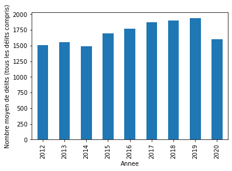

```python
import matplotlib.pyplot as plt
police_records_agregat.groupby(['Annee'])['Delits enregistres'].mean().plot(kind='bar')
plt.ylabel("Nombre moyen de délits (tous les délits compris)")
plt.figure(figsize=(10, 6))
```

## 1. Quels sont les délits les plus courants à Nantes

### Top 10 des principaux délits commis en 2020

```python
# calculate the percentage change between the current and a prior year
import numpy as np
import warnings

with warnings.catch_warnings(): #to Turn off Warnings
    warnings.simplefilter('ignore')

    police_records_2020 = police_records_agregat[(police_records_agregat["Annee"] == 2020)]

police_records_2020.sort_values(by=['Delits enregistres'], ascending = False)[:10]
```

|  | Type de crime | Annee | Delits enregistres |
| --- | --- | --- | --- |
| 215 | Vols | 2020 | 16805 |
| 26 | Autres délits | 2020 | 6270 |
| 44 | Cambriolages | 2020 | 5223 |
| 35 | Blessures volontaires | 2020 | 2266 |
| 80 | Fraudes | 2020 | 1359 |
| 143 | Menaces ou chantages | 2020 | 1103 |
| 197 | Trafic et usage de stupéfiants | 2020 | 1066 |
| 152 | Port d'armes | 2020 | 709 |
| 206 | Viols | 2020 | 676 |
| 62 | Délits non sexuels contre les mineurs | 2020 | 538 |

```python
import altair as alt
# https://altair-viz.github.io/gallery/

alt.Chart(police_records_2020.sort_values(by=['Delits enregistres'], ascending = False)[:10]).mark_bar().encode(
    alt.X("Type de crime:N", sort='-y'),
    y='Delits enregistres:Q',
).properties(
        title="",
        width=500,
        height=300,
    ).encode().interactive()
```

[interactive chart not shown]

### Analyse des Vols

```python
vols = police_records_agregat[police_records_agregat['Type de crime'].str.contains("Vols")]
vols
```

|  | Type de crime | Annee | Delits enregistres |
| --- | --- | --- | --- |
| 207 | Vols | 2012 | 17796 |
| 208 | Vols | 2013 | 16942 |
| 209 | Vols | 2014 | 16233 |
| 210 | Vols | 2015 | 19042 |
| 211 | Vols | 2016 | 20516 |
| 212 | Vols | 2017 | 22772 |
| 213 | Vols | 2018 | 23058 |
| 214 | Vols | 2019 | 22503 |
| 215 | Vols | 2020 | 16805 |

```python
import datetime as dt

vols['Annee'] = vols['Annee'].astype(str)\
                        .apply(lambda x: dt.datetime.strptime(x,'%Y'))
```

```python
print(vols.info())
```

```
<class 'pandas.core.frame.DataFrame'>
Int64Index: 9 entries, 207 to 215
Data columns (total 3 columns):
Type de crime         9 non-null object
Annee                 9 non-null datetime64[ns]
Delits enregistres    9 non-null int64
dtypes: datetime64[ns](1), int64(1), object(1)
memory usage: 288.0+ bytes
None
```

#### Évolution des vols commits à Nantes

```python
def altair_visualization(dataframe):
    """
    This is where the altair chart is defined, using the pandas dataframe.

    :returns: altair chart
    """

    vols = alt.Chart(dataframe).encode(
        alt.X('Annee', axis=alt.Axis(title="Vols enregistrés entre 2012 et 2020", grid=False)),
        alt.Y("Delits enregistres:Q", axis=alt.Axis(title="Nombre de Delits enregistres", grid=False)),
    ).properties(
            title="",
            width=500,
            height=300,
        )

    return (
        vols.mark_point()
        + vols.transform_loess("Annee", "Delits enregistres").mark_line(size=0.5).encode().interactive() #ligne de lissage
    )
```

```python
altair_visualization(vols)
```

[interactive chart not shown]

#### Comparaison entre l'historique des vols et de la criminalité en générale

```python
# Sum of all crimes recorded per year.
crimes_by_year = pd.DataFrame(police_records_agregat\
                              .groupby(['Annee'],as_index=False)['Delits enregistres']\
                              .sum())

# Change datatype for years
crimes_by_year["Annee"] = crimes_by_year["Annee"].astype(str)\
                        .apply(lambda x: dt.datetime.strptime(x,'%Y'))


base = alt.Chart(crimes_by_year).mark_line(color="orange", size = 0.7).encode(
    x='Annee',
    y='Delits enregistres:Q'
)

vols_visualisation = alt.Chart(vols).encode(
    alt.X("Annee", axis=alt.Axis(title="", grid=False)),
    alt.Y("Delits enregistres:Q", axis=alt.Axis(title="Nombre de delits enregistres", grid=False)),
    ).properties(
        title="Comparaison entre l'historique des vols et de la criminalité en générale",
        width=500,
        height=300,
    )


base + vols_visualisation.mark_point() + vols_visualisation.transform_loess("Annee", "Delits enregistres").mark_line(size=0.5).encode().interactive()
```

[interactive chart not shown]

## Savoir comment la criminalité a évolué ces dernières années à Nantes.

### Top 10 des délits en augmentation

Si la tendance se poursuit, quels sont les crimes qui connaîtront la plus forte croissance à l'avenir ?

```python
# calculate the percentage change between the current and a prior year

with warnings.catch_warnings(): #to Turn off Warnings
    warnings.simplefilter('ignore')

    police_records_last_years = police_records_agregat[(police_records_agregat["Annee"] >= 2017)]

    police_records_last_years['annual_change'] = police_records_last_years.groupby(['Type de crime'])['Delits enregistres'].pct_change()

    police_records_last_years['annual_change'] = police_records_last_years['annual_change'].replace(np.inf, np.nan).fillna(0)

    police_records_last_years['cumulative_change'] = police_records_last_years.groupby(['Type de crime'])['annual_change'].cumsum()

police_records_last_years
```

|  | Type de crime | Annee | Delits enregistres | annual_change | cumulative_change |
| --- | --- | --- | --- | --- | --- |
| 5 | Atteintes à l'environnement | 2017 | 6 | 0.000000 | 0.000000 |
| 6 | Atteintes à l'environnement | 2018 | 4 | -0.333333 | -0.333333 |
| 7 | Atteintes à l'environnement | 2019 | 5 | 0.250000 | -0.083333 |
| 8 | Atteintes à l'environnement | 2020 | 4 | -0.200000 | -0.283333 |
| 14 | Attentats à l'explosif | 2017 | 0 | 0.000000 | 0.000000 |
| ... | ... | ... | ... | ... | ... |
| 206 | Viols | 2020 | 676 | 0.016541 | 0.256914 |
| 212 | Vols | 2017 | 22772 | 0.000000 | 0.000000 |
| 213 | Vols | 2018 | 23058 | 0.012559 | 0.012559 |
| 214 | Vols | 2019 | 22503 | -0.024070 | -0.011510 |
| 215 | Vols | 2020 | 16805 | -0.253211 | -0.264721 |

92 rows × 5 columns

#### Délits ayant connu la plus forte croissance selon les données des quatre dernières années

```python
police_records_last_years_ranking = police_records_last_years[(police_records_last_years["Annee"] == 2020)]\
                                                            .sort_values(by=['cumulative_change'], ascending = False)[:10]

print(police_records_last_years_ranking[["Type de crime","cumulative_change"]])

alt.Chart(police_records_last_years_ranking).mark_bar().encode(
    alt.X("Type de crime:N", sort='-y'),
    y='cumulative_change',
).properties(
        title="Délits avec une plus forte croissance selon les données des quatre dernières années",
        width=500,
        height=300,
    ).encode().interactive()
```

```
                                         Type de crime  cumulative_change
98                                           Homicides           1.600000
161                                    Prises d'otages           1.000000
188                              Tentatives d'homicide           0.891026
134  Infractions aux conditions d'entrée des étrangers           0.773750
206                                              Viols           0.256914
44                                        Cambriolages           0.129030
179                                     Sequestrations           0.124587
143                               Menaces ou chantages           0.103631
152                                       Port d'armes           0.034636
107                              Incendies volontaires           0.028560
```

[interactive chart not shown]

## 3. Si la tendance se poursuit, quels sont les crimes qui connaîtront la plus forte croissance à l'avenir.

### Méthode de prévision ARIMA

Une alternative (en l'absence de données préalables suffisantes relatives aux variables explicatives) est la prédiction basée sur une stratégie autorégressive comme le modèle ARIMA (autoregressive integrated moving average). Cette technique est implémentée notamment pour les prévisions des séries temporelles car des éléments tels qu’une possible saisonnalité y sont pris en compte, et le résultat est une extrapolation de l'avenir en fonction des éléments passés.

```python
import statsmodels.api as sm
import statsmodels.graphics.api as smg

# preparation of data for the model ML - Arima

vols_ari = vols
# datatime as index
vols_ari.index = vols_ari['Annee']
vols_ari = vols_ari['Delits enregistres']
vols_ari.head()
```

```
Annee
2012-01-01    17796
2013-01-01    16942
2014-01-01    16233
2015-01-01    19042
2016-01-01    20516
Name: Delits enregistres, dtype: int64
```

```python
# modélisation et entrainement
with warnings.catch_warnings(): #to Turn off Warnings
    warnings.simplefilter('ignore')
    mod = sm.tsa.statespace.SARIMAX(vols_ari,trend='c', order=(1,0,0)) # (p,d,q) for a non-seasonal ARIMA model

    results = mod.fit(disp=False)

# See the results of the forecast for two next years
print(results.forecast(steps=2))
```

```
2021-01-01    17753.625259
2022-01-01    18293.194791
Freq: AS-JAN, dtype: float64
```

```python
df_fcast = pd.DataFrame(results.forecast(steps=3)) # forecast for three next years
df_fcast["date"] = df_fcast.index
df_fcast = df_fcast.rename(columns={0: "delits"}).reset_index(drop=True)

print(df_fcast.info())
df_fcast
```

```
<class 'pandas.core.frame.DataFrame'>
RangeIndex: 3 entries, 0 to 2
Data columns (total 2 columns):
delits    3 non-null float64
date      3 non-null datetime64[ns]
dtypes: datetime64[ns](1), float64(1)
memory usage: 176.0 bytes
None
```

|  | delits | date |
| --- | --- | --- |
| 0 | 17753.625259 | 2021-01-01 |
| 1 | 18293.194791 | 2022-01-01 |
| 2 | 18600.097097 | 2023-01-01 |

```python
base = alt.Chart(df_fcast).mark_bar(color="orange").encode(
    x='date:T',
    y='delits:Q'
)

vols_visualisation = alt.Chart(vols.reset_index(drop=True)).encode(
    alt.X("Annee", axis=alt.Axis(title="", grid=False)),
    alt.Y("Delits enregistres:Q", axis=alt.Axis(title="Nombre de delits enregistres", grid=False)),
    ).properties(
        title="Estimation de l'évolution de la criminalité dans les années à venir",
        width=500,
        height=300,
    )

base + base.transform_loess("date", "delits").mark_line(color =  'orange', size=0.5).encode().interactive() + vols_visualisation.mark_bar() + vols_visualisation.transform_loess("Annee", "Delits enregistres").mark_line(size=0.5).encode().interactive()
```

[interactive chart not shown]

Si nous ne prenons en compte que les données historiques des enregistrements de ce délit, selon notre modèle de prévision, les prochaines années seront marquées par une augmentation des vols.

#### Prévisions pour chaque délit

```python
def altair_visualization_predictions(police_records_agregat):
    """
    This is where the altair chart is defined, using the pandas dataframe.

    :returns: altair chart

    https://altair-viz.github.io/user_guide/compound_charts.html
    """
    charts = []
    for delit in police_records_agregat['Type de crime'].unique() :
        police_records_filtre = police_records_agregat[police_records_agregat['Type de crime'].str.contains(delit)]

        with warnings.catch_warnings():
            warnings.simplefilter('ignore')
            police_records_filtre['Annee'] = police_records_filtre['Annee'].astype(str)\
                            .apply(lambda x: dt.datetime.strptime(x,'%Y'))

            police_records_ari = police_records_filtre
            # datatime as index
            police_records_ari.index = police_records_ari['Annee']
            police_records_ari = police_records_ari['Delits enregistres']

            # modélisation et entrainement
            mod = sm.tsa.statespace.SARIMAX(police_records_ari,trend='c', order=(1,0,0)) # (p,d,q) pour un modèle ARIMA non saisonnier

            results = mod.fit(disp=False)

            df_fcast = pd.DataFrame(results.forecast(steps=3))
            df_fcast["date"] = df_fcast.index
            df_fcast = df_fcast.rename(columns={0: "delits"}).reset_index(drop=True)

            prediction = alt.Chart(df_fcast).mark_bar(color="orange").encode(
            x='date:T',
            y='delits:Q'
            )

            visualisation = alt.Chart(police_records_filtre.reset_index(drop=True)).encode(
                alt.X("Annee", axis=alt.Axis(title="", grid=False)),
                alt.Y("Delits enregistres:Q", axis=alt.Axis(title="Nombre de delits enregistres", grid=False)),
                ).properties(
                    title="Estimation de l'évolution des " + delit + " dans les années à venir",
                    width=500,
                    height=300,
                )

            charts.append(alt.layer(
                prediction,
                prediction.transform_loess("date", "delits").mark_line(color =  'orange', size=0.5).encode().interactive(),
                visualisation.mark_bar(),
                visualisation.transform_loess("Annee", "Delits enregistres").mark_line(size=0.5).encode().interactive()
            ))

    return charts
```

```python
for graphique in altair_visualization_predictions(police_records_agregat):
    graphique.display()
```

[interactive chart not shown]

Selon l'analyse visuelle de ces projections, les crimes qui risquent d'augmenter dans les années à venir sont les suivants :

- Atteintes à l'environnement
- Harcèlement non sexuel
- Infractions au droit de construction
- Infractions aux conditions d'entrée des étrangers
- Proxénétisme

## 4. Est-ce qu'il a une correlation entre le crime et le chomage ?

### Récupération et préparation des données

```python
# Get data
taux_chomage = pd.read_csv(r'data\taux_chomage_pays_de_la_loire.csv', sep=';')
```

```python
print(taux_chomage.info())
taux_chomage.head()
```

```
<class 'pandas.core.frame.DataFrame'>
RangeIndex: 1554 entries, 0 to 1553
Data columns (total 4 columns):
Date               1512 non-null object
Zone               1554 non-null object
Code Région        1554 non-null int64
Taux de chômage    1533 non-null float64
dtypes: float64(1), int64(1), object(2)
memory usage: 48.7+ KB
None
```

|  | Date | Zone | Code Région | Taux de chômage |
| --- | --- | --- | --- | --- |
| 0 | 2008-04-01 | Fontenay-le-Comte | 52 | 6.3 |
| 1 | 2020-01-01 | Fontenay-le-Comte | 52 | 7.3 |
| 2 | 2020-04-01 | Fontenay-le-Comte | 52 | 7.1 |
| 3 | 2009-04-01 | Fontenay-le-Comte | 52 | 8.8 |
| 4 | 2006-07-01 | Fontenay-le-Comte | 52 | 7.4 |

```python
taux_chomage['Zone'].unique()
```

```
array(['Fontenay-le-Comte', 'La Ferté-Bernard', 'La Flèche',
       'La Roche-sur-Yon', 'Laval', 'Le Mans', 'Les Herbiers - Montaigu',
       "Les Sables-d'Olonne", 'Mayenne', 'Nantes', 'Pornic',
       'Sablé-sur-Sarthe', 'Saint-Nazaire', 'Saumur',
       'Segré-en-Anjou Bleu', 'Ancenis', 'Angers', 'Challans',
       'Château-Gontier', 'Châteaubriant', 'Cholet'], dtype=object)
```

```python
# Transform the data type from years to date
taux_chomage['Date'] = taux_chomage['Date'].apply(pd.to_datetime)
taux_chomage['Annee'] = taux_chomage['Date'].dt.year.astype('Int64')

# Filter the Nantes area
taux_chomage = taux_chomage[(taux_chomage['Zone'] == 'Nantes')]

taux_chomage.head()
```

|  | Date | Zone | Code Région | Taux de chômage | Annee |
| --- | --- | --- | --- | --- | --- |
| 79 | 2007-01-01 | Nantes | 52 | 7.3 | 2007 |
| 80 | 2017-10-01 | Nantes | 52 | 7.1 | 2017 |
| 81 | 2020-07-01 | Nantes | 52 | 7.5 | 2020 |
| 82 | 2013-04-01 | Nantes | 52 | 8.5 | 2013 |
| 83 | 2013-10-01 | Nantes | 52 | 8.3 | 2013 |

#### Calculer un taux de chômage annuel moyen

```python
# Calculate an average annual unemployment rate
taux_chomage = taux_chomage.groupby(['Annee'],as_index=False)['Taux de chômage'].mean()

print(taux_chomage.info())
taux_chomage.head()
```

```
<class 'pandas.core.frame.DataFrame'>
Int64Index: 18 entries, 0 to 17
Data columns (total 2 columns):
Annee              18 non-null int64
Taux de chômage    18 non-null float64
dtypes: float64(1), int64(1)
memory usage: 432.0 bytes
None
```

|  | Annee | Taux de chômage |
| --- | --- | --- |
| 0 | 2003 | 7.800 |
| 1 | 2004 | 7.925 |
| 2 | 2005 | 7.825 |
| 3 | 2006 | 7.675 |
| 4 | 2007 | 6.850 |

### Croisement des jeux de données

#### Ensemble de données groupées par total des délits (sans type de délit)

```python
# Dataframe grouped by total crimes (without type of crime)
police_records_unemployment = pd.merge(police_records_agregat.groupby(['Annee'])['Delits enregistres'].sum(),
                 taux_chomage,
                 on='Annee',
                 how='inner')

police_records_unemployment["Taux de chômage"] = police_records_unemployment["Taux de chômage"].round(2)

police_records_unemployment
```

|  | Annee | Delits enregistres | Taux de chômage |
| --- | --- | --- | --- |
| 0 | 2012 | 34709 | 7.82 |
| 1 | 2013 | 35832 | 8.35 |
| 2 | 2014 | 34243 | 8.57 |
| 3 | 2015 | 39071 | 8.82 |
| 4 | 2016 | 40731 | 8.30 |
| 5 | 2017 | 43076 | 7.55 |
| 6 | 2018 | 43617 | 7.10 |
| 7 | 2019 | 44515 | 6.72 |
| 8 | 2020 | 36911 | 6.62 |

```python
delits = alt.Chart(police_records_unemployment).mark_line().encode(
    alt.X('Annee:O', axis=alt.Axis(title="", grid=False)),
    alt.Y('Delits enregistres:Q', axis=alt.Axis(title="Nombre de Délits enregistres", grid=False, titleColor='blue')),
    ).properties(
        title="",
        width=500,
        height=300,
    )

chomage = alt.Chart(police_records_unemployment).mark_line(color='red').encode(
    alt.X('Annee:O', axis=alt.Axis(title="", grid=False)),
    alt.Y('Taux de chômage:Q', axis=alt.Axis(title="Taux de chômage", grid=False, titleColor='red')),
    ).properties(
        title="Corrélation entre le chômage et la fréquence globale des crimes par an",
        width=500,
        height=300,
    )


alt.layer(delits, chomage).resolve_scale(
    y = 'independent'
)
```

[interactive chart not shown]

### Jointure des jeux de données (avec le type des délits)

```python
police_records_unemployment = pd.merge(police_records_agregat,
                 taux_chomage,
                 on='Annee',
                 how='inner')

police_records_unemployment["Taux de chômage"] = police_records_unemployment["Taux de chômage"].round(2)

police_records_unemployment.head()
```

|  | Type de crime | Annee | Delits enregistres | Taux de chômage |
| --- | --- | --- | --- | --- |
| 0 | Atteintes à l'environnement | 2012 | 7 | 7.82 |
| 1 | Attentats à l'explosif | 2012 | 0 | 7.82 |
| 2 | Autres délits | 2012 | 6715 | 7.82 |
| 3 | Blessures volontaires | 2012 | 1847 | 7.82 |
| 4 | Cambriolages | 2012 | 3422 | 7.82 |

```python
# Save new dataframe
path_data = os.path.join(current_folder,'data\police_records_unemployment_nantes.csv')
police_records_unemployment.to_csv(path_data)
```

### Corrélation entre le chômage et la fréquence des vols déclarés à Nantes

```python
theft_unemployment = police_records_unemployment[police_records_unemployment['Type de crime'].str.contains("Vols")]

theft_unemployment
```

|  | Type de crime | Annee | Delits enregistres | Taux de chômage |
| --- | --- | --- | --- | --- |
| 22 | Vols | 2012 | 17796 | 7.82 |
| 45 | Vols | 2013 | 16942 | 8.35 |
| 68 | Vols | 2014 | 16233 | 8.57 |
| 91 | Vols | 2015 | 19042 | 8.82 |
| 114 | Vols | 2016 | 20516 | 8.30 |
| 137 | Vols | 2017 | 22772 | 7.55 |
| 160 | Vols | 2018 | 23058 | 7.10 |
| 183 | Vols | 2019 | 22503 | 6.72 |
| 206 | Vols | 2020 | 16805 | 6.62 |

```python
theft_unemployment_normalized = (theft_unemployment[["Delits enregistres","Taux de chômage"]]-theft_unemployment[["Delits enregistres","Taux de chômage"]].min())/(theft_unemployment[["Delits enregistres","Taux de chômage"]].max()-theft_unemployment[["Delits enregistres","Taux de chômage"]].min())

print(theft_unemployment_normalized.head())
```

```
     Delits enregistres  Taux de chômage
22             0.229011         0.545455
45             0.103883         0.786364
68             0.000000         0.886364
91             0.411575         1.000000
114            0.627546         0.763636
```

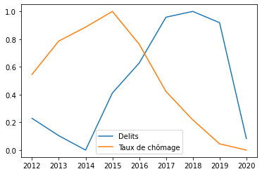

```python
with warnings.catch_warnings(): #to Turn off Warnings
    warnings.simplefilter('ignore')
    theft_unemployment["delits_normalises"] = theft_unemployment_normalized["Delits enregistres"]
    theft_unemployment["chomage_normalise"] = theft_unemployment_normalized["Taux de chômage"]

# plot lines
plt.plot(theft_unemployment["Annee"], theft_unemployment["delits_normalises"], label = "Delits")
plt.plot(theft_unemployment["Annee"], theft_unemployment["chomage_normalise"], label = "Taux de chômage")
plt.legend()
plt.show()
```

### Correlation

```python
# Calculate the spearmans's correlation between two variables
from scipy.stats import pearsonr

corr, _ = pearsonr(theft_unemployment["delits_normalises"], theft_unemployment["chomage_normalise"])
print('Spearmans correlation: %.3f' % corr) # Correlation between unemployment and the frequency of reported theft in Nantes
```

[output not shown]

#### Correlation entre 2018 - 2020

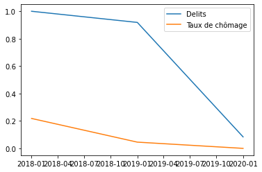

```python
theft_unemployment = theft_unemployment[(theft_unemployment["Annee"] >= 2018)]


with warnings.catch_warnings(): #to Turn off Warnings
    warnings.simplefilter('ignore')
    theft_unemployment["Annee"] = theft_unemployment["Annee"].astype(str)\
                        .apply(lambda x: dt.datetime.strptime(x,'%Y'))

    theft_unemployment["delits_normalises"] = theft_unemployment_normalized["Delits enregistres"]
    theft_unemployment["chomage_normalise"] = theft_unemployment_normalized["Taux de chômage"]

# plot lines
plt.plot(theft_unemployment["Annee"], theft_unemployment["delits_normalises"], label = "Delits")
plt.plot(theft_unemployment["Annee"], theft_unemployment["chomage_normalise"], label = "Taux de chômage")
plt.legend()
plt.figure(figsize=(15, 15))
plt.show()
```

```python
# Calculate the spearmans's correlation between two variables
corr, _ = pearsonr(theft_unemployment["delits_normalises"], theft_unemployment["chomage_normalise"])
print('Spearmans correlation: %.3f' % corr) # Correlation between unemployment and the frequency of reported theft in Nantes
```

[output not shown]

Il convient toutefois de mentionner que le taux de chômage n'est pas le seul indicateur de la situation de l'emploi de la population économiquement active. Une analyse parallèle peut être faite entre les demandes d'emploi enregistrées dans Pole emploi, par exemple.